# Simulation d’un super-prêtre et d’un super-livreur

```r
purrr::walk(fs::dir_ls("R"), source)
```

```r
library(targets)
library(tarchetypes)
library(tidyverse)
library(tidymodels)
library(hms)
library(dbscan)

set.seed(2022)
theme_set(theme_bw())
```

# 1 Simulation des conducteurs

## 1.1 Super-pretre

- time_start: **1000 trajets à 8h** (à 28800 secondes) et **1000 trajets à 17h** (61200 secondes), avec une très petite variabilité.
- distance: les **2000 trajets** sont de **5 km**, avec une petite variabilité.

```r
pretre <-
  tibble(
    time_start = as_hms(c(seq(28700, 28900, length.out = 1000), seq(61100, 61300, length.out = 1000))),
    distance = seq(4.95, 5.05, length.out = 2000)
  ) %>%
  mutate(
    time_start_norm = (as.numeric(time_start) * 2 * pi) / 86400,
    cos_time_start = cos(time_start_norm),
    sin_time_start = sin(time_start_norm)
  ) %>%
  select(
    -time_start_norm
  )
```

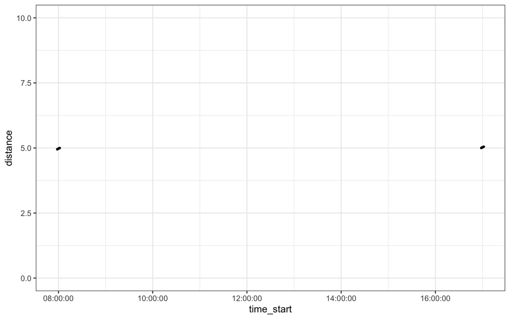

```r
ggplot(pretre, aes(x = time_start, y = distance)) +
  geom_point(size = 0.5, alpha = 0.4) +
  ylim(c(0, 10))
```

## 1.2 Super-livreur

- time_start: les 2000 trajets sont uniformément distribués entre minuit et 23h59.
- distance: les 2000 trajets sont uniformément distribués entre 1 et 10 km.

```r
livreur <-
  tibble(
    time_start = as_hms(sample(seq(1, 86400, length.out = 2000))),
    distance = sample(seq(1, 10, length.out = 2000))
  ) %>%
  mutate(
    time_start_norm = (as.numeric(time_start) * 2 * pi) / 86400,
    cos_time_start = cos(time_start_norm),
    sin_time_start = sin(time_start_norm)
  ) %>%
  select(
    -time_start_norm
  )
```

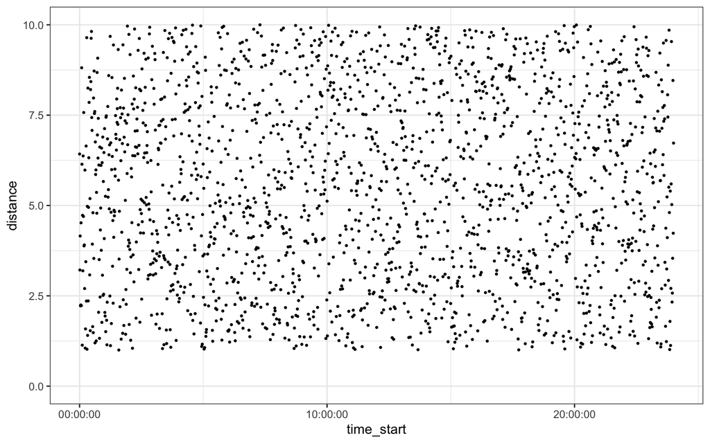

```r
ggplot(livreur, aes(x = time_start, y = distance)) +
  geom_point(size = 0.5) +
  ylim(c(0, 10))
```

# 2 LOFs

## 2.1 Calcul des LOFs

On centre et on réduit les variables (pour l’heure de la journée, j’utilise les variables *cos_time_start* et *sin_time_start*)

```r
rec_pretre <-
  recipe(~ ., data = pretre) %>%
  step_rm(time_start) %>%
  step_normalize(all_predictors()) %>%
  prep()

rec_livreur <-
  recipe(~ ., data = livreur) %>%
  step_rm(time_start) %>%
  step_normalize(all_predictors()) %>%
  prep()


pretre_baked <- bake(rec_pretre, new_data = pretre)
livreur_baked <- bake(rec_livreur, new_data = livreur)
```

On calcule les LOFs pour chacun des trajets de 2 conducteurs (j’ai choisi k = 10)

```r
lofs_pretre <- lof(pretre_baked, minPts = 10)
lofs_livreur <- lof(livreur_baked, minPts = 10)
```

## 2.2 Densité des LOFs

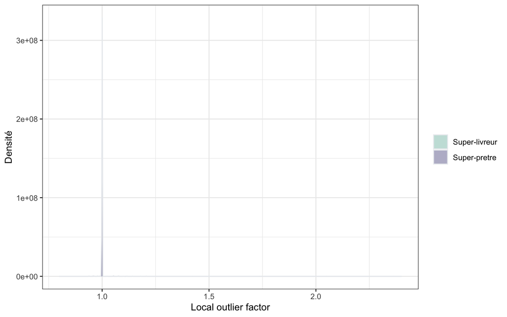

```r
plot_data <-
  tibble(
    lofs = c(lofs_pretre, lofs_livreur),
    conducteur = c(rep("Super-pretre", 2000), rep("Super-livreur", 2000))
  )

ggplot(plot_data, aes(x = lofs, fill = conducteur)) +
  geom_density(color = "#e9ecef", alpha = 0.4) +
  scale_fill_manual(name = NULL, values = c("#69b3a2", "#404080")) +
  scale_x_continuous(name = "Local outlier factor", limits = c(0.8, 2.4)) +
  ylab("Densité")
```

- Ça donne des distributions dégénérées avec tout le poids en 1 parce que de la manière que j’ai simulé (uniformément), tous les points ont la même densité locale.
- Les LOFs ne mesurent donc pas exactement le « degré de routine ».
- Selon moi, les LOFs mesurent à quel point un conducteur fait des trajets en dehors de ses trajets habituels. Et « habituel » est différent d’un conducteur à l’autre. Pour le super-prêtre, « habituel » est 5km à 8h ou à 17h. Pour le super-livreur, « habituel » est entre 1 et 10 km à n’importe quelle heure de la journée.

# 3 Mahalanobis